# Data Cleaning And Setup

Swetha Byluppala

12/11/2019

### DESCRIPTION OF DATA SOURCES

1. Copy of Cage_5_2017_2019:

The file contains single sheet(Scallop_Cage_Tagged_2017-2018) of data with columns “Date Time” from 08/23/2017 to 06/22/2019, “Temp (°F) #20178444” with temperature data, empty columns for “Coupler Detached”, “Coupler Attached”, “Host Connected”, “Stopped”, “End Of File”.

2. Copy of Cage_5_GSI_2019:

The file contains three sheets of data namely “DATA”, “Event Data”, “Details”. “Data” sheet contains temperature data and light intensity data from 06/30/2019 to 07/25/2019. “Event Data” contains logs of when data is collected with columns Date, Button Down and Button Up representing when the data was collected. “Details” sheet contains specifications of devices, series of temperatures and series of intensity as a summary of data from the sheet “DATA”.

3. Copy of Cage_6_2018_2019:

The file contains single sheet(scallopcage6) of data with columns “Date Time” from 11/15/2018 to 06/22/2019 every 30 minutes, “Temp (°F) #20178444” with temperature data, empty columns for “Coupler Detached”, “Coupler Attached”, “Host Connected”, “Stopped”, “End Of File”. This file is the data collected from the cage number 6.

4. Copy of GSI Data Sheet:

The file contains two sheets of data, “Lantern Net GSI’s” and “Pivot Table 3”. “Lantern Net GSI’s” is data about various dimensions of weight relating to the scallops as well as the vessels they were contained in, position in the water, and their sex. Collected from 07/10/2019 to 08/29/2019. “Pivot Table 3” is a dynamic summary table of first sheet.

5. Copy of Net_2_2018_2019:

Temperature data from 11/15/2018 to 06/22/2019 every 30 minutes. It has 10520 rows including the header. The header includes the following columns: “Date Time”, “Temp (°F) #10558683”,“Coupler Detached”, “Coupler Attached”, “Host Connected”, “Stopped” , “End Of File”

6. Copy of Net_5_Bottom_GSI_2019:

It includes three sheets i.e. ‘DATA’, ‘Event data’, ‘Details’. The ‘DATA’ sheet includes temperature and luminance intensity data from 06/30/2019 to 8/15/19 collected every 15 minutes, from the bottom of net 5. It has 4454 rows including the header and title. The header includes the following columns: " Date Time, GMT -0400" , “Temp, °F”, “Intensity”,“lum/ft²”

The ‘Event Data’ sheet includes the temperature logged for 2 mins. It has 20 rows including the header and title. The header includes the following columns: “Date Time, GMT -0400”,“Button Down”, “Button Up”,“Host Connect”,“EOF”. The ‘Details’ sheet includes the details for the devices, intensity statistics, and event type.

7. Copy of Net_5_Top_GSI_Top:

It also includes three sheets i.e. ‘DATA’, ‘Event data’, ‘Details’. The ‘DATA’ sheet includes temperature and luminance intensity data from 06/30/2019 to 08/15/2019 collected every 15 minutes, from the top of net 5. It has 4454 rows including the header and title. The header includes the following columns: " Date Time, GMT -0400" , “Temp, °F”, “Intensity”,“lum/ft²”

The ‘Event Data’ sheet includes the temperature logged for 15 secs. It has 5 rows including the header and title. The header includes the following columns: “Date Time GMT -0400”,“Button Down”,“Button Up”,“Host Connect”,“EOF”

The ‘Details’ sheet includes the details for the devices, temperature and intensity statistics, and event type.

8. GSI Data Sheet:

Includes same data as copy of GSI sheet, but expanded to also include average GSI of the various net and cage data collected that day. It also splits the averages for the nets and cage GSI as well. The date range includes everything from Copy of GSI Data Sheet starting at 07/10/2019, but runs all the way through 10/11/2019

### INTELLECTUAL POLICY CONSTRAINTS

Phoebe and the other stakeholders behind Hurricane Island’s Scallop data collecting have not, at this point, specified any particular restraints or concerns about the sharing or publishing of data. However, until further clarification is given, we are laboring under the assumption that data will remain confidential to the organization unless specified to us otherwise.

### META DATA

All files pertaining to the Cage #/Net # contain the same columns, as follows * Temperature - Recorded in Fahrenheit with the devices temperature probes * Intensity, lum ft2 - A measure of the amount of light sensed at the location of the temperature probe, this can vary based on the time of day as well as how clear the water is in that particular area.

##### GSI Data Sheet Info -

- Surface H20 Temperature - Average water surface temperature measured in Celsius.
- Gear Type - The designation of what type of Gear the scallops were contained in, either a “Cage” or a “Lantern Net”.
- Level/Position # - The location that the scallops were kept in, relative to their gear types.
  - Cage - Labeled by 2 character code. First character is T, M, or B meaning Top, Middle, and Bottom, respectively. The Second character is an L or R, meaning Left or Right, respectively. For instance: TL means “Top Left”
  - Lantern Net - Labeled at numerical levels 1-10 each representing the depth of that level of the net, approximately spaced 1 feet apart. 1 = 1 foot deep, 10 = 10 feet deep.
- Sex - The biological sex of the specimen, designated as M for “Male” and F for “Female
- Shell Height - Height of the specimens shell measured in mm.
- Total Viscera Weight (VW) - The total weight of the scallop’s guts after being shucked out of the shell, measured in grams.
- Meat Weight (MW) - Weight of the main, edible muscle of the scallop, measured in grams.
- Gonad Weight (GW) - Weight of the reproductive organs of the scallop, measured in grams.
- Shell Weight (SW) - Weight of scallop shell once the viscera was removed, measured in grams.
- GSI - Gonadosomatic Index, a measure of is the calculation of the gonad mass as a proportion of the total body mass. It is represented by the formula: GSI = [gonad weight / total tissue weight] × 100.
- Average GSI - The Average GSI of the specimens collected that day.

### STEP-TO- STEP PROCEDURE FOR DATA CLEANING

Here is the step by step procedure to setup a project with clean datasets.

- Assumption:
  - R and Rstudio are installed.
  - Following data sheets are saved in the working directory.
    - Copy of Cage_5_2017_2019.xlsx
    - Copy of Cage_5_GSI_2019.xlsx
    - Copy of Cage_6_2018_2019.xlsx
    - Copy of GSI Data Sheet.xlsx
    - Copy of Net_2_2018_2019.xlsx
    - Copy of Net_5_Bottom_GSI_2019.xlsx
    - Copy of Net_5_Top_GSI_Top.xlsx
    - GSI Data Sheet.xlsx

##### STEPS:

0. Set up the working directory
1. Install libraries

```r
library(tidyverse)
library(readxl)
library(dplyr)
library(reshape2)
```

```r
Copy_of_Cage_5_2017_2019 <- read_excel("Copy of Cage_5_2017_2019.xlsx",
    col_types = c("date", "numeric", "skip",
        "skip", "skip", "skip", "skip"))
```

3. Run the following code to update column names to eliminate space, comma or parenthesis in the names. Replace the name of the sheet accordingly in the highlighted areas.

```r
names(Copy_of_Cage_5_2017_2019)<-str_replace_all(names(Copy_of_Cage_5_2017_2019),c(" "=".",","="","\\(.*\\)"=""))
```

4. Run the following command to write the edited view to a csv file. This file will be saved to the current working directory.

```r
write.csv(Copy_of_Cage_5_2017_2019, 'Copy_of_Cage_5_2017_2019_cleaned.csv', row.names = FALSE)
```

5. Repeat the steps 2 to 4 for all the data sheets.

### OVERVIEW-LEVEL SCRIPTS AND RESULTS FOR BASIC STATS

#### Differences in growth rate of scallops in different cages

- Read the data from the csv file into the respective dataframes.

```r
GSI_Data_Sheet_cleaned <- read_csv("GSI_Data_Sheet_cleaned.csv")
Copy_of_Cage_6_2018_2019_cleaned <- read_csv("Copy_of_Cage_6_2018_2019_cleaned.csv", col_types = cols(Date.Time = col_datetime(format = "%Y-%m-%d %H:%M:%S")))
```

```r
Copy_of_Net_2_2018_2019_cleaned <- read_csv("Copy_of_Net_2_2018_2019_cleaned.csv",
col_types = cols(`Date.Time` = col_datetime(format = "%Y-%m-%d %H:%M:%S")))
```

```r
Copy_of_Cage_5_GSI_2019_cleaned <- read_csv("Copy_of_Cage_5_GSI_2019_cleaned.csv", col_types = cols(`Date.Time.GMT.-0400` = col_datetime(format = "%Y-%m-%d %H:%M:%S")))
```

- These steps create a bar chart that compares the different types of weight measurements across the cage types that they were kept in:
- Summarise means of the different categories of weight, grouped by cage type.

```r
gear_GSI <- GSI_Data_Sheet_cleaned %>% group_by(Gear.Type) %>% summarise(GSI = mean(GSI), Viscera = mean(Total.Viscera.Weight.), Meat = mean(Meat.Weight.), Gonad = mean(Gonad.Weight.), Shell = mean(Shell.Weight., na.rm = TRUE))
```

- Melt data into a format compatible with ggplot, grouped by “Gear.Type”

```r
gear_GSI_long <- melt(gear_GSI, id = "Gear.Type")
```

- Create plot of data, store in global variable

```r
gear_plot <- ggplot(gear_GSI_long, aes(Gear.Type, value)) + geom_bar(aes(fill = variable), position = "dodge", stat = "identity")
```

- Add labels to graph

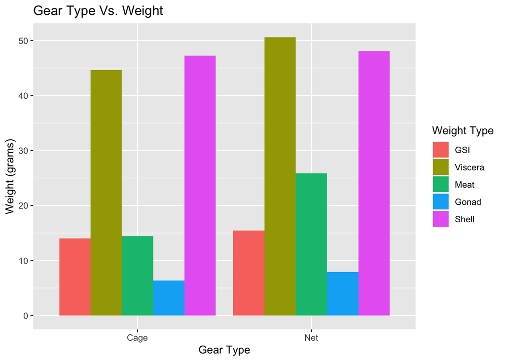

```r
gear_plot + labs(title = "Gear Type Vs. Weight", x= "Gear Type", y = "Weight (grams)", fill = "Weight Type")
```

#### Temperature gradient over 2 years (2017 - 2019)

- These steps create a line graph that shows the temperature over 2017 till 2019.
- Read the csv file with column type

```r
cagetemp <- read_csv("Copy_of_Cage_5_2017_2019_cleaned.csv", col_types = cols(Date.Time = col_datetime(format = "%Y-%m-%d %H:%M:%S")))
```

```r
tempavg <- setNames(aggregate(cagetemp$`Temp...#20178444`, by=list(cagetemp$Date.Time), mean), c("Date", "Avg_temp"))
```

- Create plot of data

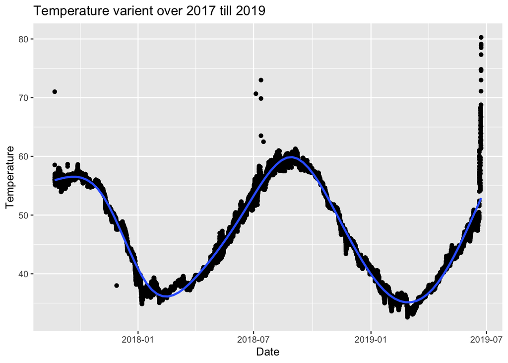

```r
ggplot(data = tempavg,mapping=aes(x=Date,y=Avg_temp)) + geom_point() + geom_smooth()+
  labs(x= "Date",y="Temperature")+
ggtitle("Temperature varient over 2017 till 2019")
```

#### The effect of temperature on the Average GSI for scallops in cages.

- This will show the graph between the Average GSI and the Average temperature for the caged scallops.
  - Generate the average temperature per day for Copy_of_Cage_5_GSI_2019_cleaned.

```r
Copy_of_Cage_5_GSI_2019_cleaned$`Date.Time.GMT.-0400` <- as.Date(Copy_of_Cage_5_GSI_2019_cleaned$`Date.Time.GMT.-0400`)
Cage5Average <- setNames(aggregate(Copy_of_Cage_5_GSI_2019_cleaned$`Temp.°F`, by=list(Copy_of_Cage_5_GSI_2019_cleaned$`Date.Time.GMT.-0400`), mean), c("Date", "Avg_temp"))
```

- Structure of dataframe Cage5Average

```r
str(Cage5Average)
```

```
## 'data.frame':    26 obs. of  2 variables:
##  $ Date    : Date, format: "2019-06-30" "2019-07-01" ...
##  $ Avg_temp: num  51.4 51.3 51.5 52 52 ...
```

- Summary of dataframe Cage5Average

```r
summary(Cage5Average)
```

```
##       Date               Avg_temp
##  Min.   :2019-06-30   Min.   :51.33
##  1st Qu.:2019-07-06   1st Qu.:52.01
##  Median :2019-07-12   Median :53.46
##  Mean   :2019-07-12   Mean   :53.39
##  3rd Qu.:2019-07-18   3rd Qu.:54.48
##  Max.   :2019-07-25   Max.   :55.74
```

- Fetch only the Cage Gear Type from the GSI_Data_Sheet.

```r
GSI_Data_sheet_cage <- subset(GSI_Data_Sheet_cleaned, Gear.Type == "Cage")
```

- Merge the temperature dataframe with the GSI dataframe.

```r
GSI_Temp_Cage <- merge(GSI_Data_sheet_cage, Cage5Average, by.x="Date", by.y = "Date", sort = TRUE)
```

- Summarise mean of temperature and GSI, grouped by Date.

```r
temp_GSI <- GSI_Temp_Cage %>% group_by(Date) %>% summarise(GSI = mean(GSI), Temp = mean(Avg_temp), Gear.Type = "Cage", na.rm = TRUE)
```

- Plot temperature with GSI

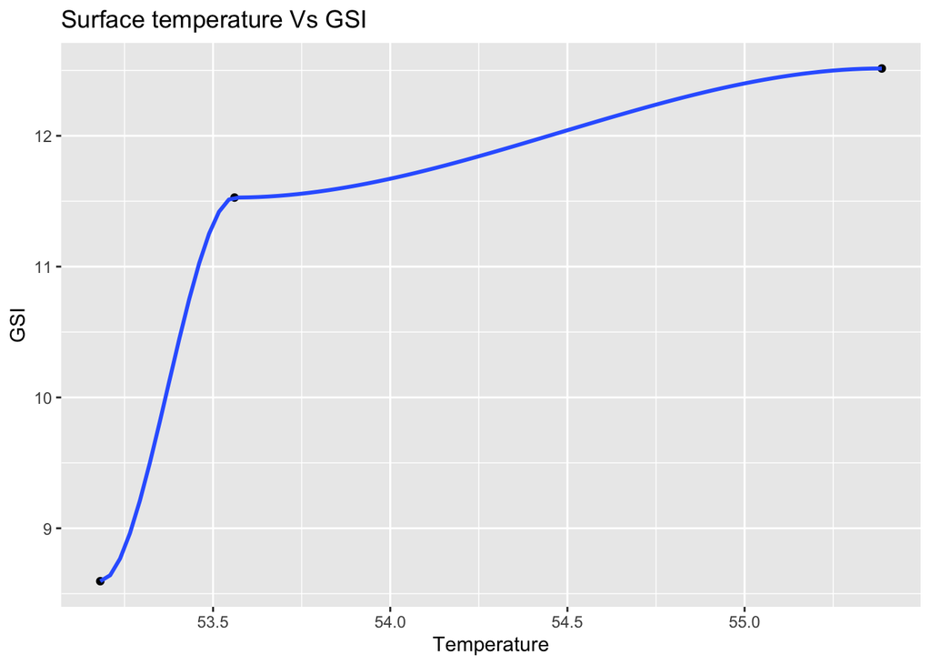

```r
ggplot(data = temp_GSI, mapping = aes(x=Temp, y=GSI)) + geom_point() + geom_smooth()+
labs(x= "Temperature",y="GSI")+
  ggtitle("Surface temperature Vs GSI")
```

#### 5. Temperature and Intensity difference in Net top and Net Bottom

- These steps create a line graph to show differences in temperature and intensity in Net top and Net bottom.
- Read the data from the csv file into the dataframe Copy_of_Net_5_Top_GSI_Top_cleaned.

```r
Copy_of_Net_5_Top_GSI_Top_cleaned <- read_csv("Copy_of_Net_5_Top_GSI_Top_cleaned.csv", col_types = cols(`Date.Time.GMT.-0400` = col_datetime(format = "%Y-%m-%d %H:%M:%S")))
```

- Generate the average temperature per day for Net Top

```r
Copy_of_Net_5_Top_GSI_Top_cleaned$`Date.Time.GMT.-0400` <- as.Date(Copy_of_Net_5_Top_GSI_Top_cleaned$`Date.Time.GMT.-0400`)
Net5TopAverage <- setNames(aggregate(Copy_of_Net_5_Top_GSI_Top_cleaned$`Temp.°F`, by=list(Copy_of_Net_5_Top_GSI_Top_cleaned$`Date.Time.GMT.-0400`), mean), c("Date", "Avg_temp_top"))
```

- Structure of dataframe Net5TopAverage

```r
str(Net5TopAverage)
```

```
## 'data.frame':    47 obs. of  2 variables:
##  $ Date        : Date, format: "2019-06-30" "2019-07-01" ...
##  $ Avg_temp_top: num  52.2 52.5 52.5 53.2 53.1 ...
```

- Summary of dataframe Net5TopAverage

```r
summary(Net5TopAverage)
```

```
##       Date             Avg_temp_top
##  Min.   :2019-06-30   Min.   :52.17
##  1st Qu.:2019-07-11   1st Qu.:54.19
##  Median :2019-07-23   Median :55.82
##  Mean   :2019-07-23   Mean   :55.33
##  3rd Qu.:2019-08-03   3rd Qu.:56.48
##  Max.   :2019-08-15   Max.   :57.53
```

- Read the data from the csv file into the dataframe Copy_of_Net_5_Bottom_GSI_2019_cleaned.

```r
Copy_of_Net_5_Bottom_GSI_2019_cleaned <- read_csv("Copy_of_Net_5_Bottom_GSI_2019_cleaned.csv", col_types = cols(`Date.Time.GMT.-0400` = col_datetime(format = "%Y-%m-%d %H:%M:%S")))
```

- Generate the average temperature per day for Net Bottom

```r
Copy_of_Net_5_Bottom_GSI_2019_cleaned$`Date.Time.GMT.-0400` <- as.Date(Copy_of_Net_5_Bottom_GSI_2019_cleaned$`Date.Time.GMT.-0400`)

Net5BottomAverage <- setNames(aggregate(Copy_of_Net_5_Bottom_GSI_2019_cleaned$`Temp.°F`, by=list(Copy_of_Net_5_Bottom_GSI_2019_cleaned$`Date.Time.GMT.-0400`), mean), c("Date", "Avg_Temp_bottom"))
```

- Structure of dataframe Net5BottomAverage

```r
str(Net5BottomAverage)
```

```
## 'data.frame':    47 obs. of  2 variables:
##  $ Date           : Date, format: "2019-06-30" "2019-07-01" ...
##  $ Avg_Temp_bottom: num  51.9 51.9 52 52.5 52.4 ...
```

- Summary of dataframe Net5BottomAverage

```r
summary(Net5BottomAverage)
```

```
##       Date            Avg_Temp_bottom
##  Min.   :2019-06-30   Min.   :51.87
##  1st Qu.:2019-07-11   1st Qu.:53.79
##  Median :2019-07-23   Median :55.34
##  Mean   :2019-07-23   Mean   :54.83
##  3rd Qu.:2019-08-03   3rd Qu.:56.09
##  Max.   :2019-08-15   Max.   :56.86
```

- Merge the dataframes.

```r
Net5TopVsBottom = setNames(merge(Net5TopAverage,Net5BottomAverage, by="Date"), c("Date", "Avg_temp_Top", "Avg_temp_bottom"))
```

- Structure of dataframe Net5TopVsBottom

```r
str(Net5TopVsBottom)
```

```
## 'data.frame':    47 obs. of  3 variables:
##  $ Date           : Date, format: "2019-06-30" "2019-07-01" ...
##  $ Avg_temp_Top   : num  52.2 52.5 52.5 53.2 53.1 ...
##  $ Avg_temp_bottom: num  51.9 51.9 52 52.5 52.4 ...
```

- Summary of dataframe Net5TopVsBottom

```r
summary(Net5TopVsBottom)
```

```
##       Date             Avg_temp_Top   Avg_temp_bottom
##  Min.   :2019-06-30   Min.   :52.17   Min.   :51.87
##  1st Qu.:2019-07-11   1st Qu.:54.19   1st Qu.:53.79
##  Median :2019-07-23   Median :55.82   Median :55.34
##  Mean   :2019-07-23   Mean   :55.33   Mean   :54.83
##  3rd Qu.:2019-08-03   3rd Qu.:56.48   3rd Qu.:56.09
##  Max.   :2019-08-15   Max.   :57.53   Max.   :56.86
```

- Melt data of the Temperature

```r
Net5TopVsBottom_long <- melt(Net5TopVsBottom, id = "Date")
```

- Create plot of data, store in global variable for temperature

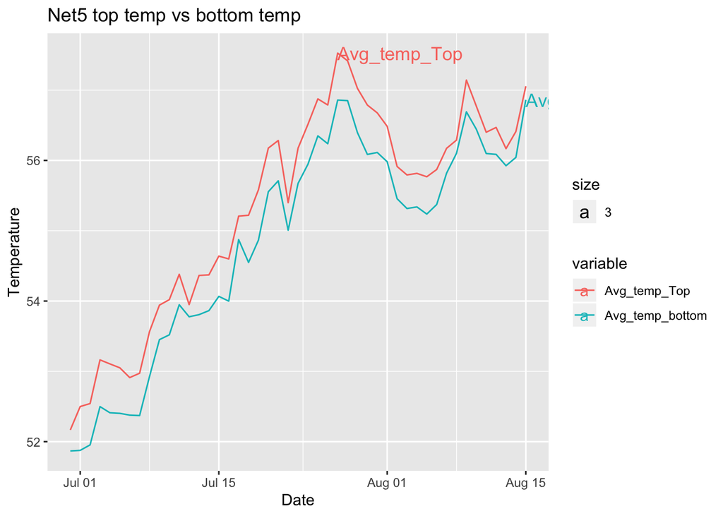

```r
ggplot(data = Net5TopVsBottom_long, mapping = aes(x= Date, y= value, color = variable))+
geom_line()+
geom_text(data = Net5TopVsBottom_long %>% group_by(variable) %>% filter(value== max(value)), aes(label= variable, x= Date,y= value,size = 3, hjust = 0))+
labs(x= "Date",y="Temperature")+
ggtitle("Net5 top temp vs bottom temp")
```

The graph is plotted to see the difference in the temperatures between top and bottom of Nets. Values are collected daily. The average of temperatures is calculated for each day and plotted against date for both Net top and Net bottom. From the graph it can be observed that the temperatures at top and bottom both follow the same trend and shows the difference is almost constant with few differences July first week and August second week.

- Generate the average intensity per day.

```r
Net5TopAverageInt <- setNames(aggregate(Copy_of_Net_5_Top_GSI_Top_cleaned$`Intensity..lum/ft²`, by=list(Copy_of_Net_5_Top_GSI_Top_cleaned$`Date.Time.GMT.-0400`), mean), c("Date", "Avg_int_top"))
```

- Structure of dataframe Net5TopAverage

```r
str(Net5TopAverageInt)
```

```
## 'data.frame':    47 obs. of  2 variables:
##  $ Date       : Date, format: "2019-06-30" "2019-07-01" ...
##  $ Avg_int_top: num  436 739 788 969 1010 ...
```

- Summary of dataframe Net5TopAverage

```r
summary(Net5TopAverageInt)
```

```
##       Date             Avg_int_top
##  Min.   :2019-06-30   Min.   : 202.4
##  1st Qu.:2019-07-11   1st Qu.: 435.6
##  Median :2019-07-23   Median : 581.0
##  Mean   :2019-07-23   Mean   : 605.8
##  3rd Qu.:2019-08-03   3rd Qu.: 775.5
##  Max.   :2019-08-15   Max.   :1018.4
```

- Generate the average Intensity per day at Bottom.

```r
Net5BottomAverageInt <- setNames(aggregate(Copy_of_Net_5_Bottom_GSI_2019_cleaned$`Intensity..lum/ft²`, by=list(Copy_of_Net_5_Bottom_GSI_2019_cleaned$`Date.Time.GMT.-0400`), mean), c("Date", "Avg_Temp_bottom"))
```

- Structure of dataframe Net5TopAverage

```r
str(Net5BottomAverageInt)
```

```
## 'data.frame':    47 obs. of  2 variables:
##  $ Date           : Date, format: "2019-06-30" "2019-07-01" ...
##  $ Avg_Temp_bottom: num  62.4 134.2 101.1 120.3 62.7 ...
```

- Summary of dataframe Net5TopAverage

```r
summary(Net5BottomAverageInt)
```

```
##       Date            Avg_Temp_bottom
##  Min.   :2019-06-30   Min.   :  2.221
##  1st Qu.:2019-07-11   1st Qu.: 14.449
##  Median :2019-07-23   Median : 27.982
##  Mean   :2019-07-23   Mean   : 35.094
##  3rd Qu.:2019-08-03   3rd Qu.: 43.203
##  Max.   :2019-08-15   Max.   :134.231
```

- Merge the dataframes.

```r
Net5TopVsBottomInt = setNames(merge(Net5TopAverageInt,Net5BottomAverageInt, by="Date"), c("Date", "Avg_Intensity_Top", "Avg_Intensity_bottom"))
```

- Structure of dataframe Net5TopVsBottom of Intensity

```r
str(Net5TopVsBottomInt)
```

```
## 'data.frame':    47 obs. of  3 variables:
##  $ Date                : Date, format: "2019-06-30" "2019-07-01" ...
##  $ Avg_Intensity_Top   : num  436 739 788 969 1010 ...
##  $ Avg_Intensity_bottom: num  62.4 134.2 101.1 120.3 62.7 ...
```

- Summary of dataframe Net5TopVsBottom of Intensity

```r
summary(Net5TopVsBottomInt)
```

```
##       Date            Avg_Intensity_Top Avg_Intensity_bottom
##  Min.   :2019-06-30   Min.   : 202.4    Min.   :  2.221
##  1st Qu.:2019-07-11   1st Qu.: 435.6    1st Qu.: 14.449
##  Median :2019-07-23   Median : 581.0    Median : 27.982
##  Mean   :2019-07-23   Mean   : 605.8    Mean   : 35.094
##  3rd Qu.:2019-08-03   3rd Qu.: 775.5    3rd Qu.: 43.203
##  Max.   :2019-08-15   Max.   :1018.4    Max.   :134.231
```

- Melt data of the Intensity

```r
Net5TopVsBottomInt_long <- melt(Net5TopVsBottomInt, id = "Date")
```

- Create plot of data, store in global variable for intensity

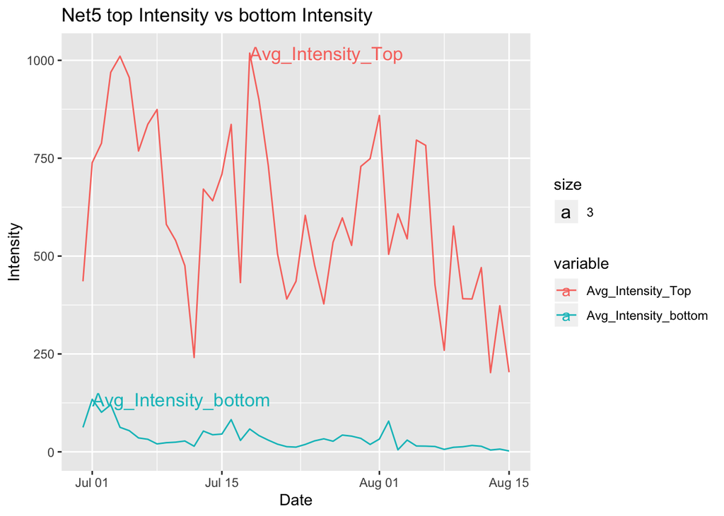

```r
ggplot(data = Net5TopVsBottomInt_long, mapping = aes(x= Date, y= value, color = variable))+
geom_line()+
geom_text(data = Net5TopVsBottomInt_long %>% group_by(variable) %>% filter(value== max(value)), aes(label= variable, x= Date,y= value,size = 3, hjust = 0))+
labs(x= "Date",y="Intensity")+
ggtitle("Net5 top Intensity vs bottom Intensity")
```